# Gossip Girl

Paulina Rybacka

29 05 2018

# Plotkara (serial telewizyjny)

Plotkara – amerykański serial młodzieżowy oparty na serii powieści Cecily von Ziegesar o tym samym tytule. Narratorem serialu jest blogerka - Plotkara o nieznanej tożsamości (dowiadujemy się kim jest dopiero w ostatnim odcinku 6 sezonu). Opisuje ona skandaliczne życie uczniów prywatnej szkoły na Upper East Side w Nowym Jorku.

https://en.wikipedia.org/wiki/Gossip_Girl

[figure not shown]

# Odcinki

| SERIA | ILOŚĆ ODCINKÓW | PREMIERA SERII | FINAŁ SERII |  |
| --- | --- | --- | --- | --- |
| 1 | 18 | 19 września 2007 | 19 maja 2008 |  |
| 2 | 25 | 1 września 2008 | 18 maja 2009 |  |
| 3 | 22 | 14 września 2009 | 17 maja 2010 |  |
| 4 | 22 | 13 września 2010 | 16 maja 2011 |  |
| 5 | 24 | 26 września 2011 | 14 maja 2012 |  |
| 6 | 10 | 8 października 2012 | 17 grudnia 2012 |  |

# Informacje o serialu

- gatunek: serial młodzieżowy
- kraj produkcji: Stany Zjednoczone
- twórcy: Josh Schwartz, Stephanie Savage
- główne role: Blake Lively, Leighton Meester, Penn Badgley, Chace Crawford, Taylor Momsen, Ed Westwick, Kelly Rutherford, Matthew Settle, Jessica Szohr, Kaylee DeFer

## TOP 10 adresów wartych odwiedzenia z planu Gossip Girl

1. The Campbell Apartment (*15 Vanderbilt Avenue*)
2. Gramercy Tavern (*42 E 20th Street*)
3. Dylan’s Candy Bar (*1011 Third Avenue*)
4. Veselka (*144 2nd Avenue*)
5. Erin McKenna’s Bakery NYC (*248 Broome Street*)
6. Pinkberry (*1039 2nd Avenue*)
7. The Empire Hotel Bar (*44 W 63rd Street*)
8. Communitea (*11-18 46th Road, Long Island City*)
9. Ladurée (*864 Madison Avenue oraz 398 West Broadway*)
10. The Oak Room (*10 Central Park South* )

Aby zobaczyć jak wyglądają te miejsca, wystarczy kliknąć [tutaj](https://miumag.pl/travel/nowojorski-przewodnik-z-planu-gossip-girl-10-top-a-7549)

`Blair Waldorf: "Once again the world has proven anything you can do, I can do it better.`

## Teraz reszta (nie na temat)

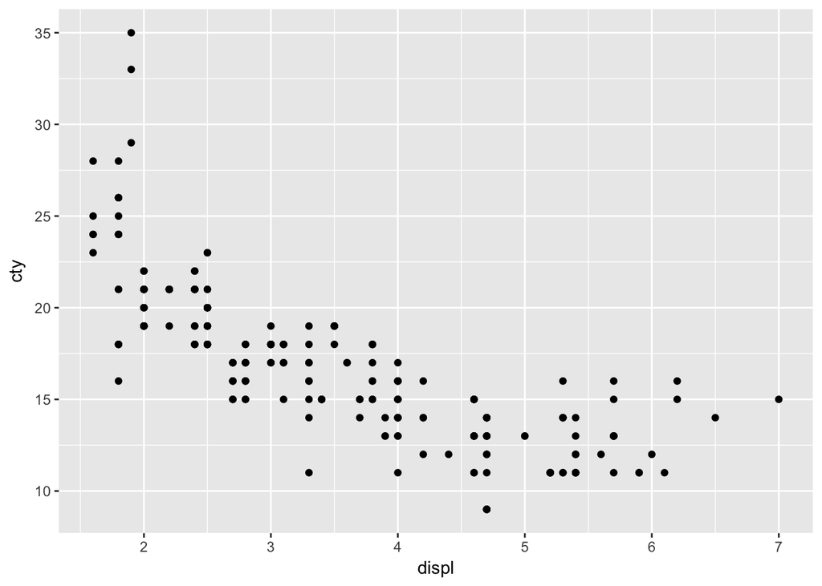

```r
library(ggplot2)
ggplot(data = mpg) +
geom_point(mapping = aes(x = displ , y = cty))
```

```r
library(tidyverse)
diamonds %>% filter(cut == "Very Good")
```

| carat | cut | color | clarity | depth | table | price | x | y | z |
| --- | --- | --- | --- | --- | --- | --- | --- | --- | --- |
| 0.24 | Very Good | J | VVS2 | 62.8 | 57.0 | 336 | 3.94 | 3.96 | 2.48 |
| 0.24 | Very Good | I | VVS1 | 62.3 | 57.0 | 336 | 3.95 | 3.98 | 2.47 |
| 0.26 | Very Good | H | SI1 | 61.9 | 55.0 | 337 | 4.07 | 4.11 | 2.53 |
| 0.23 | Very Good | H | VS1 | 59.4 | 61.0 | 338 | 4.00 | 4.05 | 2.39 |
| 0.30 | Very Good | J | SI1 | 62.7 | 59.0 | 351 | 4.21 | 4.27 | 2.66 |
| 0.23 | Very Good | E | VS2 | 63.8 | 55.0 | 352 | 3.85 | 3.92 | 2.48 |
| 0.23 | Very Good | H | VS1 | 61.0 | 57.0 | 353 | 3.94 | 3.96 | 2.41 |
| 0.31 | Very Good | J | SI1 | 59.4 | 62.0 | 353 | 4.39 | 4.43 | 2.62 |
| 0.31 | Very Good | J | SI1 | 58.1 | 62.0 | 353 | 4.44 | 4.47 | 2.59 |
| 0.23 | Very Good | G | VVS2 | 60.4 | 58.0 | 354 | 3.97 | 4.01 | 2.41 |

[output cut: 9990 more lines]

[figure not shown]